# Detecting Phishing URLs from Structural and Content-Based Web Features

## 6.3 Improved Model — Decision Tree

```r
set.seed(42)
tree_model <- train(
  label ~ .,
  data = train_data,
  method = "rpart",
  trControl = ctrl,
  metric = "ROC",
  tuneLength = 8
)

tree_model
```

```
## CART
##
## 188636 samples
##     62 predictor
##      2 classes: 'Phishing', 'Legitimate'
##
## No pre-processing
## Resampling: Cross-Validated (5 fold)
## Summary of sample sizes: 150909, 150909, 150909, 150908, 150909
## Resampling results across tuning parameters:
##
##   cp           ROC        Sens       Spec
##   0.002191788  0.9930383  0.9891525  0.9909993
##   0.002253703  0.9925987  0.9890782  0.9898035
##   0.003492001  0.9918487  0.9877409  0.9883389
##   0.004507405  0.9899860  0.9870598  0.9847238
##   0.006649661  0.9871213  0.9854624  0.9820634
##   0.012209619  0.9819572  0.9753826  0.9829440
##   0.036158304  0.9711678  0.9682624  0.9715425
##   0.909443261  0.7771897  0.5826516  0.9717278
##
## ROC was used to select the optimal model using the largest value.
## The final value used for the model was cp = 0.002191788.
```

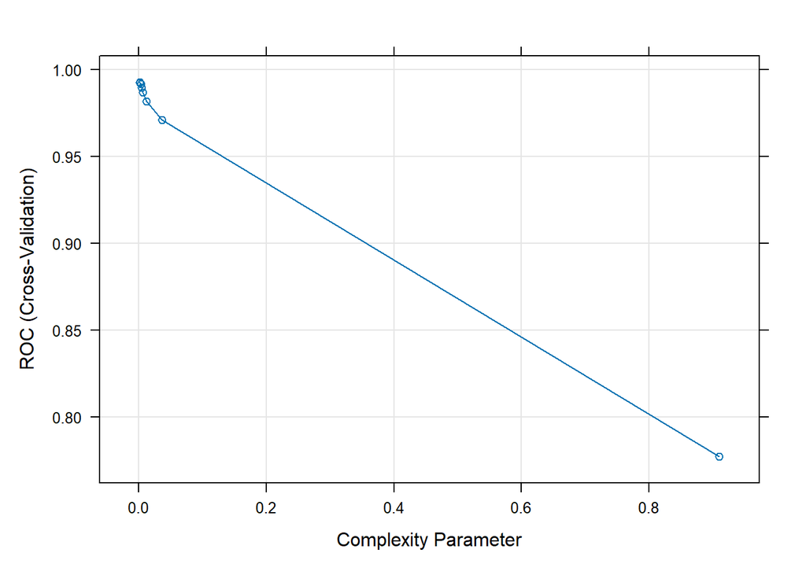

```r
plot(tree_model)
```

**Decision:** A **decision tree** (`rpart` via `caret`) is used as the improved model. Unlike logistic regression, trees can capture non-linear thresholds and interactions (e.g. “IF `NoOfExternalRef` is low AND `IsHTTPS` is false THEN phishing”) without any manual feature-interaction engineering. `tuneLength = 8` asks `caret` to automatically try 8 candidate complexity-parameter (`cp`) values and pick the one with the best cross-validated ROC-AUC on the training set — this is the same 5-fold CV setup used for the baseline, so the two models are compared on equal footing.

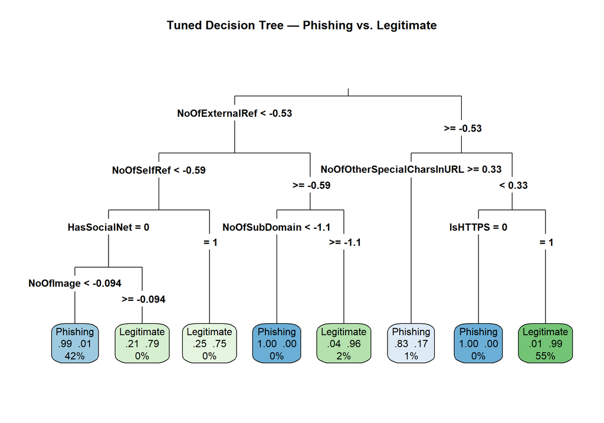

```r
rpart.plot(tree_model$finalModel,
           type = 3, extra = 104, fallen.leaves = TRUE,
           main = "Tuned Decision Tree — Phishing vs. Legitimate",
           box.palette = "auto")
```

**Observation:** The tree’s top splits are expected to involve the strongest bivariate predictors identified in earlier sections — count-based content signals (`NoOfExternalRef`, `NoOfSelfRef`) and `IsHTTPS` typically appear at or near the root, consistent with the correlation and grouped-summary findings in Sections 3.4 and 3.5.